# PSDV Pre requisite test Solutions

### Divyansh Sharma (24110113)

## 1. List Operations and Basic Statistics

```python
def mean(array):
    return sum(array)/len(array)

def std(array):
    avg = mean(array)
    variance = 0
    for value in array:
        variance += (avg - value)**2
    variance = variance/len(array)
    return round(variance**0.5,2)

def median(array):
    array.sort()
    if len(array)%2==0:
        index = int(len(array)/2)
        return (array[index] + array[index-1])/2
    else:
        index = int((len(array)-1)/2)
        return array[index]


array = list(range(1,21))
Sum = 0
product = 1
for i in array:
    if i%2==0:
        Sum+=i
    else:
        product*=i
print("Sum of even numbers is:", Sum)
print("product of odd numbers is:", product)
print("Mean of the list is:", mean(array))
print("Median of the list is:", median(array))
print("Standard deviation of the list is:", std(array))
```

```
Sum of even numbers is: 110
product of odd numbers is: 654729075
Mean of the list is: 10.5
Median of the list is: 10.5
Standard deviation of the list is: 5.77
```

Mutable objects can have their contents modified after they are created. You can change, add, or remove elements without creating a new object. When global mutable objects are passed into local spaces (e.g. passed into functions), changes in the local environment are reflected globally. e.g. - Lists, Dictionary, Sets etc.

Immutable objects cannot be modified after they are created. Any operation that seems to modify them actually creates a new object. Changes in local environment are not reflected globally. e.g. - String, Tuple, Integers, Floats etc.

## 2. Fibonacci Sequence

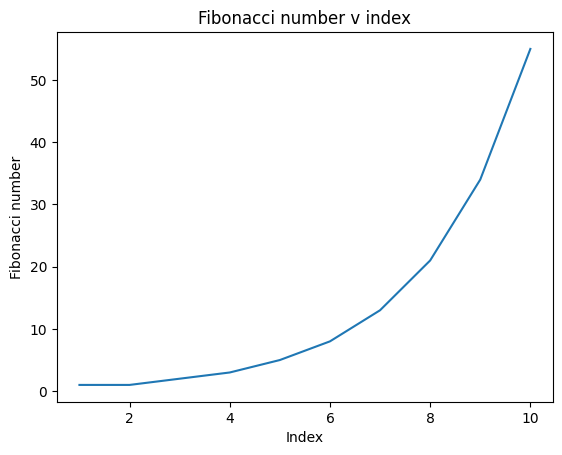

```python
#limit N = 1476
import matplotlib.pyplot as plt

def fibonacciList(n):
    array = []
    pen = 1
    ult = 1
    for i in range(n):
        if i==0:
            array.append(pen)
            continue
        array.append(ult)
        pen,ult = ult,pen+ult
    return array

N = int(input())
yAxis = fibonacciList(N)
xAxis = list(range(1,N+1))

plt.plot(xAxis,yAxis)
plt.xlabel("Index")
plt.ylabel("Fibonacci number")
plt.title("Fibonacci number v index")
plt.show()
```

## 4. List Manipulation

```python
def median(array):
    if len(array)%2==0:
        index = int(len(array)/2)
        return (array[index] + array[index-1])/2
    else:
        index = int((len(array)-1)/2)
        return array[index]

def mean(array):
    return sum(array)/len(array)

array = [3, 5, 7, 9, 11, 13]
array.insert(3,6)
print(array)
array.pop(array.index(7))
print(array)
array = array[::-1]
print(array)
print("mean of modified array:",mean(array))
print("median of modified array:",median(array))
```

```
[3, 5, 7, 6, 9, 11, 13]
[3, 5, 6, 9, 11, 13]
[13, 11, 9, 6, 5, 3]
mean of modified array: 7.833333333333333
median of modified array: 7.5
```

## 5. User Input and Basic Statistics

```
Mean: 39.857142857142854
Smallest number: 5.0
Largest number: 96.0
```

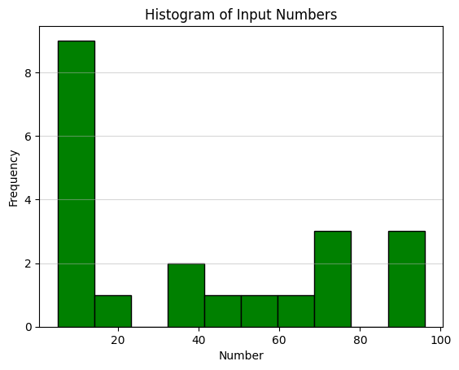

```python
import matplotlib.pyplot as plt
def mean(array):
    return(sum(array)/len(array))

input_numbers = input("Enter a comma-separated list of numbers: ")
numbers = [float(num.strip()) for num in input_numbers.split(",")]

if not numbers:
    raise ValueError("No numbers provided.")

mean_value = mean(numbers)
smallest = min(numbers)
largest = max(numbers)

print(f"Mean: {mean_value}")
print(f"Smallest number: {smallest}")
print(f"Largest number: {largest}")

plt.hist(numbers, bins=10, color='green', edgecolor='black')
plt.title("Histogram of Input Numbers")
plt.xlabel("Number")
plt.ylabel("Frequency")
plt.grid(axis='y', alpha=0.5)


plt.show()
```

## 6. Palindrome Check

```python
string = input()
newstring = ""
for i in string:
    if not(i.isspace()):
        newstring+=i.lower()
print(newstring == newstring[::-1])

#input is "A man a plan a canal Panama"
```

```
True
```

## 7. Dictionary Operations

```
A
B
F
H
J
```

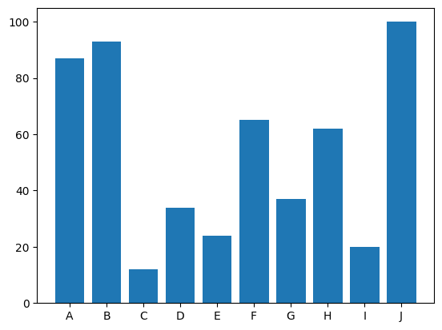

```python
import matplotlib.pyplot as plt

def mean(array):
    return sum(array)/len(array)


Marks = {"A":87,
         "B":93,
         "C":12,
         "D":34,
         "E":24,
         "F":65,
         "G":37,
         "H":62,
         "I":20,
         "J":100}

meanMarks = mean(Marks.values())
for name in Marks:
    if Marks[name]> meanMarks:
        print(name)

plt.bar(Marks.keys(),Marks.values())
plt.title = "Marks"
plt.xlabel = "Name"
plt.ylabel = "Marks"
plt.show()
```

## 8. Tuple List Creation

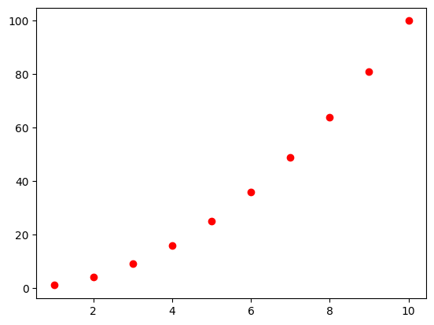

```python
import matplotlib.pyplot as plt
points = []
for i in range(1,11):
    points.append((i,i**2))
x = [i[0] for i in points]
y = [i[1] for i in points]
plt.scatter(x,y,c = "red")
plt.show()
```

## 9. Merging Dictionaries

```python
dict1 = {'a': 10, 'b': 20}
dict2 = {'b': 5, 'c': 15}
handleDict = dict1
for key in dict2:
    if key in handleDict:
        handleDict[key]+=dict2[key]
    else:
        handleDict[key]=dict2[key]
print(handleDict)
```

```
{'a': 10, 'b': 25, 'c': 15}
```

## 10. Character Frequency

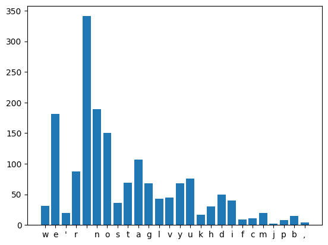

```python
import matplotlib.pyplot as plt
def characterFrequency(string):
    string = string.lower()
    characters = {}
    for char in string:
        if char not in characters:
            characters[char] = 1
        else:
            characters[char] += 1
    return characters

characters = characterFrequency(input("Enter the string:"))
plt.bar(characters.keys(),characters.values())
plt.title = "Frequency distribution of characters in the given string"
plt.xlabel = "Characters"
plt.ylabel = "Frequency"
plt.show()
```

- Input given: We're no strangers to love You know the rules and so do I A full commitment's what I'm thinkin' of You wouldn't get this from any other guy I just wanna tell you how I'm feeling Gotta make you understand Never gonna give you up Never gonna let you down Never gonna run around and desert you Never gonna make you cry Never gonna say goodbye Never gonna tell a lie and hurt you We've known each other for so long Your heart's been aching, but you're too shy to say it Inside, we both know what's been going on We know the game and we're gonna play it And if you ask me how I'm feeling Don't tell me you're too blind to see Never gonna give you up Never gonna let you down Never gonna run around and desert you Never gonna make you cry Never gonna say goodbye Never gonna tell a lie and hurt you Never gonna give you up Never gonna let you down Never gonna run around and desert you Never gonna make you cry Never gonna say goodbye Never gonna tell a lie and hurt you We've known each other for so long Your heart's been aching, but you're too shy to say it Inside, we both know what's been going on We know the game and we're gonna play it I just wanna tell you how I'm feeling Gotta make you understand Never gonna give you up Never gonna let you down Never gonna run around and desert you Never gonna make you cry Never gonna say goodbye Never gonna tell a lie and hurt you Never gonna give you up Never gonna let you down Never gonna run around and desert you Never gonna make you cry Never gonna say goodbye Never gonna tell a lie and hurt you Never gonna give you up Never gonna let you down Never gonna run around and desert you Never gonna make you cry Never gonna say goodbye Never gonna tell a lie and hurt you

## 11. Remove Duplicates

```python
def removeDuplicates(array):
    handler = []
    for element in array:
        if element in handler:
            continue
        else:
            handler.append(element)
    return handler

def mean(array):
    return sum(array)/len(array)

def median(array):
    array.sort()
    if len(array)%2==0:
        index = int(len(array)/2)
        return (array[index] + array[index-1])/2
    else:
        index = int((len(array)-1)/2)
        return array[index]

array = [1,2,3,2,42,4,645,7,4,532,46,3,563,57,73,6,436,534,5,1,23,41,352,4,78]
array = removeDuplicates(array)
print("The list after removing duplicate elements is:", array)
print("Mean of the new list after removing duplicates is:", mean(array))
print("Median of the new list after removing duplicates is:", median(array))
```

```
The list after removing duplicate elements is: [1, 2, 3, 42, 4, 645, 7, 532, 46, 563, 57, 73, 6, 436, 534, 5, 23, 41, 352, 78]
Mean of the new list after removing duplicates is: 172.5
Median of the new list after removing duplicates is: 44.0
```

## 12. String Operations

```
longest string is supercalifragilistic
Number of strings starting with a vowel are 1
```

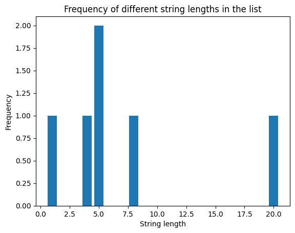

```python
import matplotlib.pyplot as plt
lOs = ["lmao","Divyansh","hfaui","blith","supercalifragilistic","a"]
def vowelWordCount(array):
    count = 0
    for word in array:
        if word.lower()[0] in 'aeiou':
            count+=1
    return count

longest = max(lOs , key = len )
dic = {}
for word in lOs:
    if len(word) not in dic:
        dic[len(word)] = 1
    else:
        dic[len(word)] += 1

print("longest string is", longest)
print("Number of strings starting with a vowel are", vowelWordCount(lOs))
plt.bar(dic.keys(),dic.values())
plt.title("Frequency of different string lengths in the list")
plt.ylabel("Frequency")
plt.xlabel("String length")
plt.show()
```

## 13. Sorting Dictionaries

```python
array = [{'name': 'Alice', 'age': 25}, {'name': 'Bob', 'age': 22}, {'name':'Chris', 'age':29}]
def sortDictsByKey(array , key):
    return sorted(array, key = lambda x:x[key])

print(sortDictsByKey(array, 'age'))
```

```
[{'name': 'Bob', 'age': 22}, {'name': 'Alice', 'age': 25}, {'name': 'Chris', 'age': 29}]
```

## 14. Word Filtering and Sorting

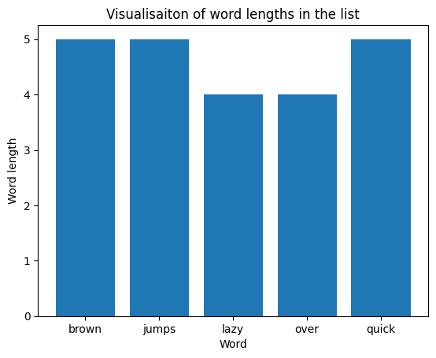

```
['brown', 'jumps', 'lazy', 'over', 'quick']
```

```python
import matplotlib.pyplot as plt
def wordHandler(string):
    words = string.split()
    i = 0
    handle = list(word for word in words if len(word)>=4)
    handle.sort()
    dic = {}
    for word in handle:
        if word not in dic:
            dic[word] = len(word)
    plt.bar(dic.keys(),dic.values())
    plt.title("Visualisaiton of word lengths in the list")
    plt.ylabel("Word length")
    plt.xlabel("Word")
    plt.show()
    return handle

print(wordHandler("The quick brown fox jumps over the lazy dog"))
```

## 15. Anagram Finder

```python
def anagramFinder(word, words):

    sortedWord = sorted(word)
    return [w for w in words if sorted(w) == sortedWord]

print(anagramFinder("listen", ["enlist", "google", "inlets", "banana"]))
```

```
['enlist', 'inlets']
```

## 16. Set Operations

```
Intersection: {4, 5}
Union: {1, 2, 3, 4, 5, 6, 7, 8}
Symmetric Difference: {1, 2, 3, 6, 7, 8}
```

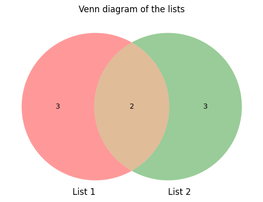

```python
import matplotlib.pyplot as plt
from matplotlib_venn import venn2
list1 = [1, 2, 3, 4, 5]
list2 = [4, 5, 6, 7, 8]
set1 = set(list1)
set2 = set(list2)

intersection = set1 & set2
union = set1 | set2
symmetric_difference = set1 ^ set2

print("Intersection:", intersection)
print("Union:", union)
print("Symmetric Difference:", symmetric_difference)

plt.figure()
venn = venn2([set1, set2], ('List 1', 'List 2'))
plt.title("Venn diagram of the lists")
plt.show()
```

## 17. File Operations

```python
numbers = [1,2,3,1,42,5,4,6,3,65,7,4,64,37,48,5,5976,2,52,3]
with open("numbers.txt","w") as f:
    for number in numbers:
        f.write(f"{number}\n")
    f.close()

with open("numbers.txt","r") as f:
    sum = 0
    for number in f:
        sum += int(number)
    print("Sum of the numbers is:", sum)
    f.close()
```

```
Sum of the numbers is: 6330
```

## 18. Word Count and Frequency

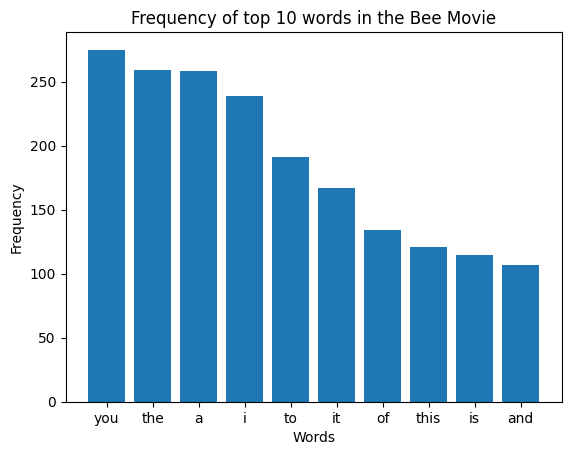

```python
import string
import matplotlib.pyplot as plt
with open("beeMovie.txt","r") as f:
    wordMap = {}
    for line in f:
        for punctuation in string.punctuation:
            line = line.replace(punctuation,'')
        words = line.strip().split()
        for word in words:
            if word.lower() not in wordMap:
                wordMap[word.lower()] = 1
            else:
                wordMap[word.lower()] += 1
    f.close()
wordMap = dict(sorted(wordMap.items(), key = lambda item : item[1], reverse = True))
plt.bar(list(wordMap.keys())[:10],list(wordMap.values())[:10])
plt.xlabel("Words")
plt.ylabel("Frequency")
plt.title("Frequency of top 10 words in the Bee Movie")
plt.show()
```

## 19. Random Number Generation

```
Mean of the numbers is: 26.09
```

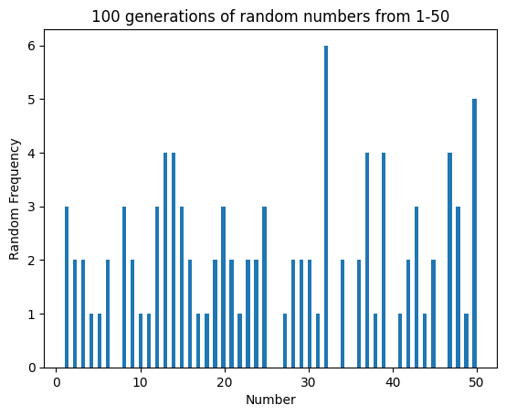

```python
import random
import matplotlib.pyplot as plt

def mean(array):
    return sum(array)/len(array)

with open("randomNumbers.txt","w") as f:
    for i in range(100):
        f.write(f"{random.randint(1,50)}\n")
    f.close()
with open("randomNumbers.txt","r") as f:
    s = 0
    array = []
    for number in f:
        array.append(int(number))
    array.sort()
    f.close()


print("Mean of the numbers is:", mean(array))
plt.hist(array, 100)
plt.xlabel("Number")
plt.ylabel("Random Frequency")
plt.title("100 generations of random numbers from 1-50")
plt.show()
```

## 20. CSV file operations

```
Sum : 123775
```

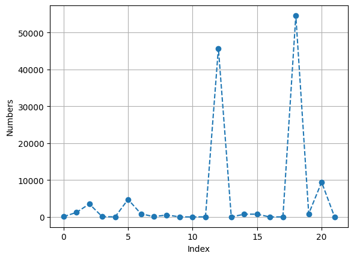

```python
import pandas as pd
import matplotlib.pyplot as plt

data = pd.read_csv('data.csv')
column= 'Numbers'
column_sum = data[column].sum()
print(f"Sum : {column_sum}")

plt.plot(data[column], marker='o', linestyle='--')

plt.xlabel('Index')
plt.ylabel(column)
plt.grid(True)
plt.show()
```

## 21. Basic Statistics.py

```
Mean of the numbers is: 32.43478260869565
Median of the numbers is: 36
Mode of the numbers is: 8
Standard Deviation of the numbers is: 21.38
```

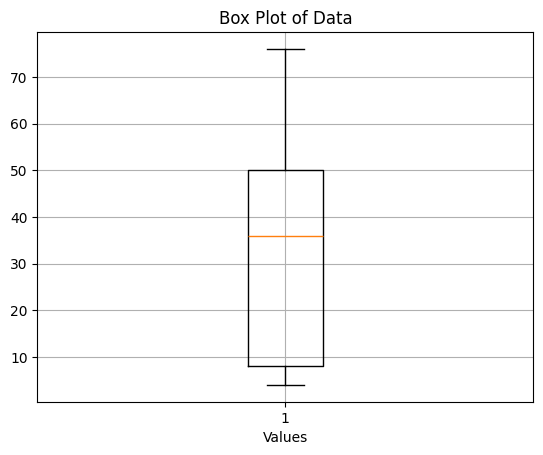

```python
import matplotlib.pyplot as plt

def mean(array):
    return sum(array)/len(array)

def std(array):
    avg = mean(array)
    variance = 0
    for value in array:
        variance += (avg - value)**2
    variance = variance/len(array)
    return round(variance**0.5,2)

def median(array):
    array.sort()
    if len(array)%2==0:
        index = int(len(array)/2)
        return (array[index] + array[index-1])/2
    else:
        index = int((len(array)-1)/2)
        return array[index]

def mode(array):
    hashmap = {}
    for i in array:
        if i in hashmap:
            hashmap[i] += 1
        else:
            hashmap[i] = 1
    return max(hashmap , key = hashmap.get)


numbers = [54,36,43,56,5,76,8,24,53,46,7,5,8,46,54,7,47,8,32,55,4,36,36]
print("Mean of the numbers is:", mean(numbers))
print("Median of the numbers is:", median(numbers))
print("Mode of the numbers is:", mode(numbers))
print("Standard Deviation of the numbers is:", std(numbers))

plt.boxplot(numbers)
plt.title("Box Plot of Data")
plt.xlabel("Values")
plt.grid(True)
plt.show()
```

## 22. Normalization

```
[0.09278350515463918, 0.10309278350515463, 0.32989690721649484, 0.0, 0.6597938144329897, 0.8556701030927835, 0.31958762886597936, 0.5463917525773195, 0.8969072164948454, 0.9896907216494846, 0.09278350515463918, 1.0, 0.041237113402061855, 0.20618556701030927, 0.5257731958762887]
```

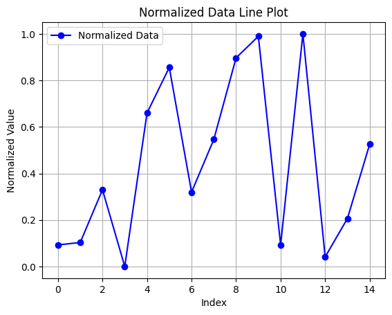

```python
import matplotlib.pyplot as plt
def normalise(array):
    handle = []
    minimum = min(array)
    maximum = max(array)
    for i in array:
        n = (i - minimum)/(maximum - minimum)
        handle.append(n)
    return handle

array = [12,13,35,3,67,86,34,56,90,99,12,100,7,23,54]
normalised = normalise(array)
print(normalised)
plt.plot(normalised, marker='o', linestyle='-', color='blue', label='Normalized Data')
plt.title("Normalized Data Line Plot")
plt.xlabel("Index")
plt.ylabel("Normalized Value")
plt.grid(True)
plt.legend()
plt.show()
```

## 23. Even or Odd

```python
number = int(input("please enter a number:"))
print("Even") if number%2==0 else print("Odd")
#input 9
```

```
Odd
```

## 24. Grade Calculator

```python
mark = int(input())
if mark<0 or mark>100:
    print("Please enter integer number from 0 - 100")
    exit()
if mark in range(0,40):
    print("F")
elif mark in range(40,60):
    print("D")
elif mark in range(60,70):
    print("C")
elif mark in range(70,80):
    print("B")
else:
    print("A")

#input 29
```

```
F
```

## 25. Leap Year Checker

```python
year = int(input())
if year%4 != 0:
    print("Not a leap year")
else:
    if year%100 == 0:
        if year%400 == 0:
            print("Leap year")
        else:
            print("Not a leap year")
    else:
        print("Leap year")

#input 2025
```

```
Not a leap year
```